# Examen Parcial Estadistica computacional

Eduardo Hidalgo 117036 & Bernardo Garcia 130901

October 5, 2017

# Ejercicio 1 “Relación entre boostrap e inferencia bayesiana”

## 1.1 Boostrap Parametrico

### Escribe la función de verosimilitud

De la definición de la distribución posterior bayesiana se tiene :

$$P(\vec(\theta)|x)=\frac{P(x|\theta)P(\theta)}{P(x)}$$

donde:

$P(\theta|\vec(x))$ : es la **distribución posterior bayesiana** del parametro $\theta$

$P(\theta)$ : es la **función de verosimilitud** del parámetro $\theta$

$P(\theta)$ : es la **distribución apriori** que resume nuestras crrencias iniciales del parametro

$P(x)$ : es la **evidencia** o verosimilitud marginal o inicial predictiva

En el contexto de la pregunta del exámen sabemos que:

$$P(x|\theta)=\prod_{i=1}^{n}f(x_{i}|\theta) =\prod_{i=1}^{n}\frac{1}{\sqrt{2\pi\sigma^{2}}}e^{-\frac{x_{i}^{2}}{2\sigma^{2}}}$$

Ya que $x_{i} \sim N(0,\sigma^{2}),\forall i \in [1,n]$

Para encontrar el estimador de máxima verosimilitud basta con encontrar el argumento que maximiza la función de máxima verosimilitud

Sin embargo, para facilitar la exposición algebraica, generalmente se resuelve dicho problema aplicando una transformación monotónica a la función de verosimilitud como el $ln$. Por lo que la función de log verosimilutd se define como :

$$ln(P(x|\theta))=ln(\prod_{i=1}^{n}\frac{1}{\sqrt{2\pi\sigma^{2}}}e^{-\frac{x_{i}^{2}}{2\sigma^{2}}})$$
$$=\sum_{i=1}^{n}ln(\frac{1}{\sqrt{2\pi\sigma^{2}}}e^{-\frac{x_{i}^{2}}{2\sigma^{2}}})$$
$$=\sum_{i=1}^{n}[ln(1)-\frac{1}{2}ln(2\pi)-\frac{1}{2}ln\sigma^{2}-\frac{x_{i}^{2}}{2\sigma^{2}}]$$

Y por tanto el estimador de maxima verosimilitud se define como :

$$argmax_{\sigma{2}}\sum_{i=1}^{n}[ln(1)-\frac{1}{2}ln(2\pi)-\frac{1}{2}ln\sigma^{2}-\frac{x_{i}^{2}}{2\sigma^{2}}]$$

De la C.P.O se tiene :

$$[\sigma^{2}] : \sum_{i=1}^{n}[-\frac{1}{2}\frac{1}{\sigma^{2}}+\frac{x_{i}}{2(\sigma^{2})^{2}}]=0$$

$$\Rightarrow \sum_{i=1}^{n}[\frac{1}{2\sigma^{2}}]=\sum_{i=1}^{n}[\frac{x_{i}^{2}}{(\sigma^{2})^{2}}]$$

$$\Rightarrow \sum_{i=1}^{n}\sigma^{2}=\sum_{i=1}^{n}x_{i}^{2}$$

$$\Rightarrow \sigma_{MV}^{2}=\frac{\sum_{i=1}^{n}x_{i}^{2}}{n}$$

### Estimación de la varianza usando los datos **x** y el resultado anterior :

```
##   SigmaMV FuncionR
## 1 131.291 131.8516
```

La comparación de **SigmaMV** con **FuncionR** permite ver que probablemente dplyr esta utilizando para el calculo al estimador **insesgado** de sigma $\sigma_{MV}^{2}=\frac{\sum_{i=1}^{n}x_{i}^{2}}{n-1}$

### Aproximación de la varianza de sigma cuadrada por el método bootstrap

Método Bootstrap :

```
## [1] "Media de la varianza de las replicaciones Boostrap"
```

```
## [1] 130.5896
```

```
## [1] "Desv Estd. de la varianza de las Replicaciones Boostrap"
```

```
## [1] 14.86358
```

```
## [1] "Varianza de la varianza de las Replicaciones Boostrap"
```

```
## [1] 220.9261
```

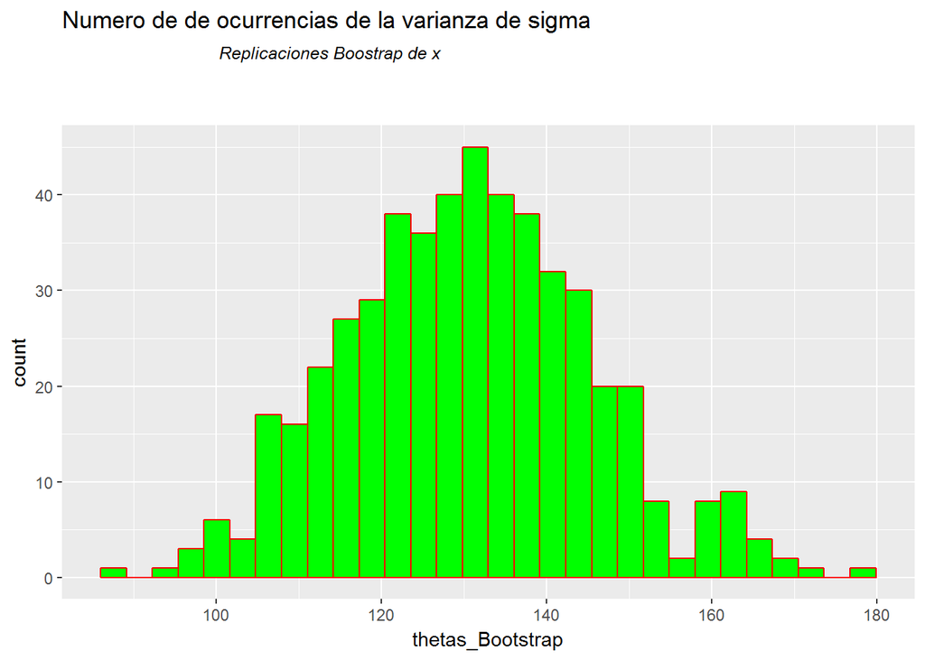

## Análisis Bayesiano

### Inferencia Bayesiana sobre $\sigma^{2}$, selección de distribución inicial Gamma Inversa y grafica de la densidad

La distribución inicial que se elige para este tipo de casos (donde $x \sim N(\mu,\sigma^{2})$ y se conoce $\mu$ pero se trata de estimar la probabilidad posterior de $\sigma^{2}$)) es la Gamma Inversa, por las siguientes razones:

- La inicial Gamma Inversa con verosimilitud Normal es una familia Conjungada (por lo que es posible llegar a una distribución posterior cerrada)
- El soporte de la Gamma Inversa es $x \in \Re^{+}$ por lo que coincide con el rango de valores que puede tomar $\sigma^{2}$

Por lo que de la primera se consigue una relación entre $\beta$ y $\alpha$

y al sustituir en dos se encuentra que :

Por último, basta con insertar el valor de $\alpha$ en la relación que encontramos :

$$\beta=131.44(92.39)=12,144$$

```r
#Aqui se especifica la funcion gama inversa
x_gamma<-rgamma(2000,shape=93.34,rate=12144)
x_igamma<-1/x_gamma



GammaInv<-stat_function(fun = dinvgamma, args = list(shape = 93.34, scale = 12144))
x_igamma<-as.data.frame(x_igamma)
```

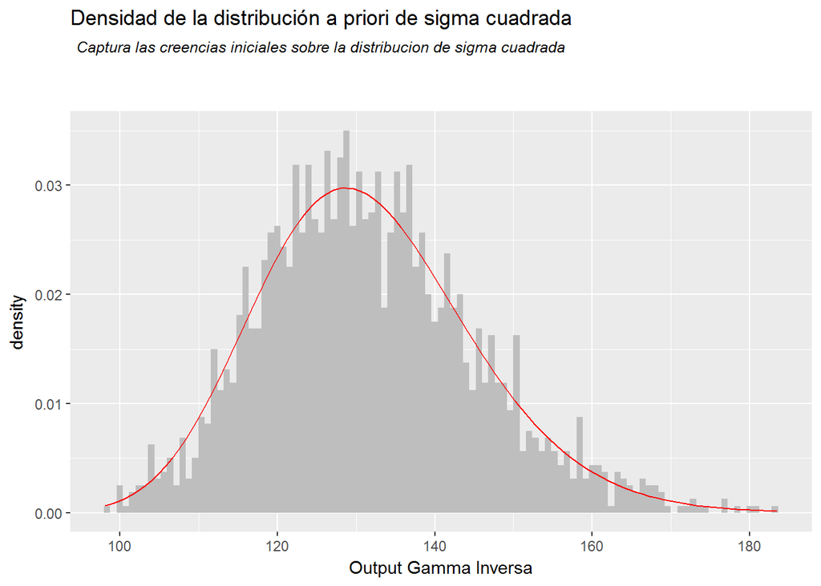